# Lecture 19: Secure multi-party computation

### Announcements

- Please pick up your card
- Reading 10 and Homework 8 are due Friday 11/14 at 6pm on Gradescope
- Test 3 is **Monday 11/17** in lecture (see [Piazza post](https://piazza.com/class/meyslgzymrs7n/post/63) about what is in scope)

### Learning outcomes

By the end of today’s lecture, you will learn:

- The distinction between protecting data at rest, in transit, and in use
- How to construct MPC against a passive Eve from cryptographic secret sharing
- How to construct MPC against an active Mallory using replication

### Review

We have now completed 3 units of the course, and have just 1 unit remaining.

1. Protecting data *integrity* using digital signatures and message authentication codes
2. Protecting data *availability* with broadcast and blockchains
3. Protecting data *confidentiality* using encryption
4. Protecting data *science* i.e., working with data you cannot see

We already saw a preview into Unit 4 when we discussed the *Boston wage gap study*.

- Objective: companies contribute payroll data to the study, while protecting data confidentiality
- Methodology: use cryptographic **secret sharing** to split the data between BU and the BWWC
- Result: we can calculate the city-wide total (i.e., the sum across all spreadsheets), but without learning any information about individual employees or employers

[figure not shown]

100talent.org website in 2017

## 19.1 Protecting data in use

Today, we will begin Unit 4 of the course on secure data analysis. This unit continues our investigation into data confidentiality (and we will sometimes also discuss data integrity).

We can sub-divide data confidentiality into three different scenarios.

1. **Protecting data at rest**, such as encrypting data on your local own hard drive
2. **Protecting data in transit**, for instance by using end-to-end encrypted messengers like Signal, WhatsApp, or iMessage
3. **Protecting data in use**, so that Alice can outsource her computation to Bob while still not allowing Bob himself to read the data!

This may sound counterintuitive to you, or perhaps even impossible. After all, if you want someone to conduct data analysis for you, don’t you have to give them your data? That’s how modern cloud computing works.

We will spend the next few weeks exploring this problem. My goal is to convince you that it is possible to **conduct data science without data sharing**.

To solve this problem, we will need a new data confidentiality tool besides encryption.

- Encryption has an all-or-nothing property: anyone who knows the symmetric key (e.g., Alice or Bob) can read everything, whereas anyone without the key (e.g., Mallory) learns nothing
- In Unit 4, the people you’re working with, the people you don’t fully trust, and your potential adversaries *are the same people* (in other words, perhaps Bob is also Mallory)

> “Cryptography is how people get things done when they need one another, don’t fully trust one another, and have adversaries actively trying to screw things up.”

> – Ben Adida

To use an analogy:

- Encryption is like putting your data inside a lockbox
- The new tools we will design in Unit 4 are like working with the data while it is inside the box

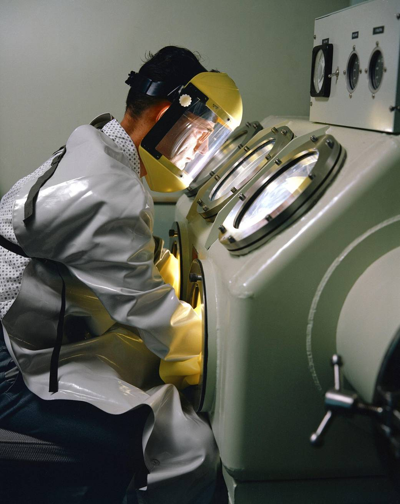

Image source: [NASA](https://www.nasa.gov/image-article/vacuum-dry-box/)

## 19.2 Secret sharing

For this journey, we will look at the one-time pad in a new way. Recall that a one-time pad uses the `xor` function $\oplus$ to protect a secret message $P$ by performing $P = K \oplus C$.

If the attacker sees the ciphertext $C$ but not the key $K$, then the cipher is *perfectly secret*.

- The adversary has learned *nothing* about the secret message, in a probabilistic sense
- Concretely, an adversary who only sees $C$ but not $K$ cannot distinguish between any two possible values $P_0$ and $P_1$ of the secret message

  $$\Pr[\text{secret is } P_0\text{, given ciphertext } C] = \Pr[\text{secret is } P_1\text{, given ciphertext } C]$$

Here’s an interesting thought experiment: what if we switch the roles of $K$ and $C$? That is, what if:

- Mallory sees the key $K$ but
- Mallory does not see the ciphertext $C$?

With a one-time pad, this scenario should never happen. But it’s illustrative to think about it anyway.

Amazingly, this is also perfectly secret!

- In the equation $P = K \oplus C$, we can think of $K$ as a “mask” that hides $C$
- But it is equally valid to think about $C$ as a mask that hides $K$

This insight leads to the idea of **cryptographic secret sharing**! With secret sharing:

- A group of parties jointly hold a secret, but
- No small coalition in the group knows the secret

### Defining secret sharing

Informally, a $(t, n)$-secret sharing scheme splits the secret $s$ into $n$ shares, such that any $t$ of the shares reveal *no information* about $s$, while any $t + 1$ shares allow complete reconstruction of the secret $s$.

A formal definition follows.

**Definition 1** Starting from a secret $s$, a *cryptographic secret sharing* scheme is defined by two algorithms:

1. `split`$(s,t,n)$ is a randomized algorithm that splits a secret $s$ into a vector of $n$ shares $[s_1, s_2, \ldots, s_n]$, such that any subset of shares of size $t + 1$ can reconstruct the original secret.
2. `reconstruct`$(s_{i_1}, \ldots, s_{i_{t+1}})$ is a deterministic algorithm that takes $t + 1$ distinct secret shares (i.e., a sub-vector of $\vec{s}$) and calculates the original secret $s$.

The scheme must satisfy two security requirements.

- *Correctness* states that if you `split` any secret $s$, then `reconstruct` always recovers the original secret $s$.
- $t$-*perfect secrecy* is defined similarly as with a one-time pad: for any two possible secrets $s$ and $r$, and for any vector of $t$ or fewer secret shares $\vec{x} = \{x_{i_1}, x_{i_2}, \ldots, x_{i_t}\}$, it is the case that:

  $$\Pr[\text{all }x_i = s_i \mid \vec{s} = \text{split}(s, t, n)] = \Pr[\text{all }x_i = r_i \mid \vec{s} = \text{split}(r, t, n)].$$

  In words: perfect secrecy says that the shares held by a coalition of $\leq t$ parties have an equal probability of being shares of $s$ or shares of $r$.

### Boolean secret sharing

Today, we will contruct two (related) secret sharing algorithms.

**Scenario.** Suppose that Susie has a secret $s$ that she wants to split between two of her friends Alice and Bob. She wants each friend to hold onto one *share* of the secret on their hard drive. This way:

- If Susie loses her secret in the future, she can recover it by talking to both of them.
- If either one of Alice or Bob are actually evil (or have their hard drive corrupted), the secret is still protected. This limits the trust that Suzie must place in each friend.

Here is a construction that allows Susie to accomplish this goal. It will `split` her $\ell$-bit secret $s$ into two shares.

1. Choose the share $s_1$ uniformly at random among all bitstrings of length $\ell$
2. Calculate $s_2 \gets s \oplus s_1$ (where $\oplus$ denotes the boolean-`xor` operation)
3. Send $s_1$ to Alice, and send $s_2$ to Bob

To `reconstruct` the secret later, calculate $s \gets s_1 \oplus s_2$.

**Theorem 1** This construction is a secret sharing scheme among $n = 2$ parties that is perfectly secret against any $t = 1$ adversarial party.

- Correctness is easy to check. Both the split and reconstruct algorithms rely on the fact that $s = s_1 \oplus s_2$.
- Perfect secrecy follows a similar argument as a one-time pad.
  - From Alice’s perspective: she knows $s_1$ but not $s_2$ or $s$. To her, the scheme looks just like a one-time pad where $s_1$ is akin to the ciphertext, and the unknown $s_2$ acts as the key that perfectly hides the message $s$.
  - From Bob’s perspective: the situation is the same! He knows $s_2$, but to him this looks just like a OTP ciphertext, and the unknown $s_1$ acts as the key that perfectly hides the message.

This proof relies on a subtle but essential probability argument: on its own, $s_2$ has the uniform distribution over all length-$\ell$ bitstrings. This is because a uniformly-random bitstring `xor`ed with a constant bitstring has a uniform distribution.

For example, suppose that the secret $s = \texttt{111..1}$. Then $s_2 = \texttt{111..1} \oplus s_1$ is the result of taking a uniformly-random bitstring and flipping all of its bits. The result also has the uniform distribution.

### Arithmetic secret sharing

We can also construct a secret sharing scheme using addition, rather than the `xor` operation. Here’s an alternative approach for Susie to `split` her secret:

1. Choose the share $s_1$ uniformly at random among all numbers that are $\ell$ bits long (i.e., the numbers 0 to $2^\ell-1$).
2. Calculate $s_2 \gets s - s_1 \bmod{2^\ell}$.
3. Send $s_1$ to Alice, and send $s_2$ to Bob.

To `reconstruct` the secret later, calculate $s \gets s_1 + s_2 \bmod{2^\ell}$. Correctness and perfect secrecy hold for essentially the same reasons as before. (Do you see why?)

Also, both boolean and arithmetic secret sharing immediately generalize to the $n$ party setting.

- Susie can `split` her secret $s$ among $n$ parties by sampling shares such that:
  $$s = s_1 + s_2 + \cdots + s_n \bmod{2^\ell}$$
- All $n$ parties must honestly participate in order to `reconstruct` the original secret $s$
- Perfect secrecy is achieved against any subset of $t = n - 1$ parties, because the final share acts like a one-time pad to hide the secret

## 19.3 Secure multi-party computation

Consider the following setting:

- There are $m$ people who possess sensitive data $x_1, x_2, \ldots, x_m$
- They want to outsource this data to a collection of computing parties $P_1, P_2, \ldots, P_n$
  - The computing parties could be the same people as the data holders
  - Or they could be different companies like cloud providers
- A data analyst proposes to compute a function $f$ of all sensitive data
- Everyone agrees to contribute their data toward data analysis $f$, and everyone believes that at most $t$ of the $n$ parties are adversarial

Cryptographically **secure multi-party computation** (often abbreviated as MPC) allows the parties to:

- Work together to calculate $y = f(x_1, \ldots, x_m)$
- Ensure that no coalition of up to $t$ computing parties can learn anything about the input data
- The data analyst (who receives the output $y$) learns nothing about the inputs beyond what can be inferred from $y$, in a Bayesian sense

Now that we understand how MPC works informally, this is usually where I would provide a scientific definition. I’m not going to do that this time though, because the formal definition of MPC is somewhat complicated. You will read about it in next week’s required reading.

Instead, I reproduce below some text from a recent bill in the U.S. Congress that provides a legal definition of MPC. (Emphasis added by me.)

> The term “secure multi-party computation” means a computerized system that enables **different participating entities** in possession of private sets of data to **link and aggregate their data sets** for the exclusive purpose of performing a finite number of pre-approved computations **without transferring or otherwise revealing any private data** to each other or anyone else.

> – [2022 U.S. Senate bill S.3952](https://www.congress.gov/bill/117th-congress/senate-bill/3952/text#id0c1c7f87d1ba4b27ac9d9025ff5fd0e5)

We can consider MPC against two kinds of adversaries (the same ones we considered for encryption):

- The passive eavesdropper Eve
- The actively-malicious adversary Mallory

Let’s begin by considering MPC against a passive eavesdropper Eve. Remember that Eve promises to follow the rules of a cryptographic protocol, but she tries to learn sensitive data along the way.

## 19.4 MPC against Eve

In general, *secure multi-party computation* (MPC) protocols have three steps:

1. The data holders **split** their secrets $x_1, x_2, \ldots, x_m$, and send one share to each computing party
2. The computing parties perform some **calculation** over the secret shares
3. The computing parties give shares of the result to the data analyst, who can **reconstruct** $y = f(\vec{x})$

Steps 1 and 3 come directly from the `split` and `reconstruct` operations of the secret sharing construction.

### MPC of addition

We have already seen how arithmetic secret sharing can be used to build a secure computation of addition. This is how we solved the Boston Women’s Workforce Council’s problem.

$a$

$b$

$c$

$a + b + c$

$a_1$

$b_1$

$c_1$

$a_1 + b_1 + c_1$

$a_2$

$b_2$

$c_2$

$a_2 + b_2 + c_2$

So we already have designed our first MPC algorithm… well, as long as the only data analysis we want to perform is addition.

The good news is that you can perform cryptographically secure multi-party computation of **any** function!

### MPC of linear functions

The BWWC idea easily extends to cover all linear functions (in the sense of linear algebra).

For instance, suppose that rather than calculating $a + b + c$, we actually wanted to compute $2a + 3b - c + 10$.

Since we are using arithmetic secret sharing, and scalar multiplication also commutes over addition, each party can just compute its share of the result.

$a$

$b$

$c$

$2a + 3b - c + 10$

$a_1$

$b_1$

$c_1$

$2a_1 + 3b_1 - c_1 + 10$

$a_2$

$b_2$

$c_2$

$2a_2 + 3b_2 - c_2 + 0$

### MPC of multiplication

Next, let’s try to multiply two secrets. Suppose that two data holders input $a$ and $b$, respectively.

$a$

$b$

$c = a \cdot b$

$a_1$

$b_1$

$\color{red}{??}$

$a_2$

$b_2$

$\color{red}{??}$

**Interactive question.** Can we use the same idea to calculate secret shares of the product $c = a \cdot b$? That is: can each party take the product of their own shares and set $c_i = a_i \cdot b_i$?

1. Yes
2. No

*Answer*. This is not as easy to compute. This time we cannot rely solely on commutativity of addition; we need to consider the distributive law as well.

Recall the relationships between the secret variables and their arithmetic shares (all equations will be mod $2^\ell$, but from now on I’m going to omit writing the modulus for brevity):
$$\begin{align*}
a &= a_1 + a_2 \\
b &= b_1 + b_2.
\end{align*}$$

Hence, we want to compute:
$$\begin{align*}
c &= a \cdot b \\
&= (a_1 + a_2) (b_1 + b_2) \\
&= a_1 b_1 + a_1 b_2 + a_2 b_1 + a_2 b_2.
\end{align*}$$

Here we reach a condundrum.

- BU can compute the term $a_1 b_1$ on its own, and the Council can compute $a_2 b_2$ on its own
- But it’s unclear how to compute the cross-terms $a_1 b_2$ and $a_2 b_1$ *without* telling the computing parties to send their shares to each other (which would break data confidentiality)

Today, I will show you one way to resolve this conundrum. It relies on two useful insights.

**Insight #1:** let’s add a third computing party.

$a$

$b$

$c = a \cdot b$

$a_1$

$b_1$

$\color{red}{??}$

$a_2$

$b_2$

$\color{red}{??}$

$a_3$

$b_3$

$\color{red}{??}$

At first glance, this might look to make the calculation even harder to perform. Now the distributive law says that we must calculate:

$$\begin{align*}
c &= (a_1 + a_2 + a_3) (b_1 + b_2 + b_3) \\
&= a_1 b_1 + a_1 b_2 + a_1 b_3 \\
&\quad + a_2 b_1 + a_2 b_2 + a_2 b_3 \\
&\quad + a_3 b_1 + a_3 b_2 + a_3 b_3. \\
\end{align*}$$

**Insight #2:** Let’s give each computing party *two* of the three shares. This is called **replicated secret sharing**.

- This is still not enough information for any $t = 1$ party to reconstruct any secrets
- But now any 2 of the $n = 3$ parties will collectively have enough information to reconstruct secrets

$a$

$b$

$c = a \cdot b$

$a_1, a_2$

$b_1, b_2$

$c_1 = a_1b_1 + a_1b_2 + a_2b_1$

$a_2, a_3$

$b_2, b_3$

$c_2 = a_2b_2 + a_2b_3 + a_3b_2$

$a_3, a_1$

$b_3, b_1$

$c_3 = a_3b_3 + a_3b_1 + a_1b_3$

The punchline here is that: now there exists a computing party that can calculate each of the 9 terms in this product! So the three computing parties can calculate $a \cdot b$ by working together in such a way that nobody has learned either $a$ or $b$.

$$\begin{align*}
c &= (a_1 + a_2 + a_3) (b_1 + b_2 + b_3) \\
&= \color{red}{a_1 b_1} + \color{red}{a_1 b_2} + \color{gray}{a_1 b_3} \\
&\quad + \; \color{red}{a_2 b_1} + \color{blue}{a_2 b_2} + \color{blue}{a_2 b_3} \\
&\quad + \; \color{gray}{a_3 b_1} + \color{blue}{a_3 b_2} + \color{gray}{a_3 b_3}. \\
\end{align*}$$

There’s just one downside here: the computing parties have two shares of $a$ and $b$, but only one share of $c$. So we cannot continue and multiply $c$ times some other secret.

This is easy to fix with some communication: each computing party gives its share to one other party.

- $P_1$ sends $c_1 + z_1$ to $P_3$
- $P_2$ sends $c_2 + z_2$ to $P_1$
- $P_3$ sends $c_3 + z_3$ to $P_2$

Now our invariant is maintained: each computing party starts with 2 out of 3 shares of each input, and completes multiplication with 2 out of 3 shares of each output.

To provide secrecy, we add some additional shares $z_1$, $z_2$, $z_3$ that are designed to sum to zero. This way they individually serve as one-time pads but cancel out in the aggregate total.

To summarize, we have constructed a secure multiplication scheme with:

- One round of network communication between the computing parties
- Correctness, since the $n = 3$ parties work together to calculate all 9 terms of $c$
- Perfect secrecy against $t = 1$ party, since this party only holds two shares of each secret
- Reconstruction by any two parties, since they collectively hold all 3 shares of the output

### MPC of everything

So far, we have seen one way to perform secure multi-party computation of $+$ and $\times$.

Importantly: $+$ and $\times$ are a Turing-complete set of gates! That is, we can write *any* data analytic as a circuit with $+$ and $\times$ gates. (This may not be the *fastest* way to compute $f$, but it will always work in principle.)

For instance, given the circuit below along with secret shares of $s$, $t$, and $x$ it is possible for the 3 computing parties to work together to calculate:

- secret shares of the intermediate value $w$
- secret shares of the final result $y$

and then `reconstruct` only the output $y$.

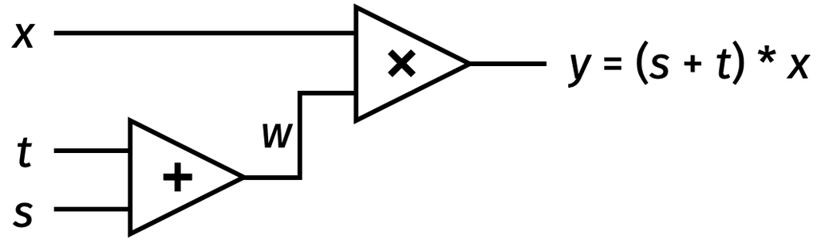

Hence, the protocol we have constructed today can do a secure computation of *any* function, as long as:

- You decompose the data analysis $f$ into a sequence of additions and multiplications
- There is an honest majority of 2 honest parties out of 3 total parties
- The one adversarial party is run by a passive eavesdropper Eve (i.e., it still follows the protocol)

It turns out that *none* of these conditions are necessary: you can also perform MPC in other ways, with a dishonest majority, and against an actively-malicious adversary Mallory.

## 19.5 MPC against Mallory

So far, our MPC protocol is only secure against a passive eavesdropper Eve. That’s because a malicious computing party Mallory can tamper with the result by adding some number to her own share.

$a$

$b$

$c = a \cdot b \color{red}{+ 10}$

$a_1, a_2$

$b_1, b_2$

$c_1 = a_1b_1 + a_1b_2 + a_2b_1 \color{red}{+ 10}$

$a_2, a_3$

$b_2, b_3$

$c_2 = a_2b_2 + a_2b_3 + a_3b_2$

$a_3, a_1$

$b_3, b_1$

$c_3 = a_3b_3 + a_3b_1 + a_1b_3$

Here is one way to stop Mallory: we can add a *fourth* computing party for even more redundancy.

- Using replicated secret sharing, we can build a secure computation protocol with $n = 4$ parties such that any $t = 1$ party learns nothing
- The data holders send 3 of 4 arithmetic shares to each computing party

$a$

$b$

$c = a \cdot b$

$a_1, a_2, a_3$

$b_1, b_2, b_3$

$c_1$

$a_2, a_3, a_4$

$b_2, b_3, b_4$

$c_2$

$a_3, a_4, a_1$

$b_3, b_4, b_1$

$c_3$

$a_4, a_1, a_2$

$b_4, b_1, b_2$

$c_4$

The math for multiplication has gotten more tedious.

$$\begin{align*}
c &= (a_1 + a_2 + a_3 + a_4) (b_1 + b_2 + b_3 + b_4) \\
&= a_1 b_1 + a_1 b_2 + a_1 b_3 + a_1 b_4 \\
&\quad + \; a_2 b_1 + a_2 b_2 + a_2 b_3 + a_2 b_4 \\
&\quad + \; a_3 b_1 + a_3 b_2 + a_3 b_3 + a_3 b_4 \\
&\quad + \; a_4 b_1 + a_4 b_2 + a_4 b_3 + a_4 b_4
\end{align*}$$

This time, I won’t write out explicitly how the shares of $c$ are calculated. But the punchline is simple:

- For each of the 16 terms, there exist **two** parties who know how to compute it
- So for any computation that Mallory performs, there is an honest party who can check her math and call her out if she cheats!

Let’s take a step back and admire what we have done so far.

- We have been able to design MPC protocols that can compute *any* data analysis
- We can protect **data confidentiality** and **data integrity** against a malicious Mallory

Next time:

- We will add **data availability** to secret sharing and MPC, in order to complete the CIA triad
- I will give some intuition about how cryptographers construct MPC protocols that are secure against more than $t = 1$ adversarial party